# Group Lab 1 - Changes in the Geography of Chinese Production

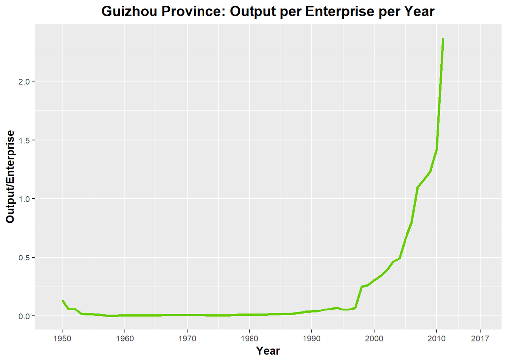

_____________________________________________________________________________________________________________________

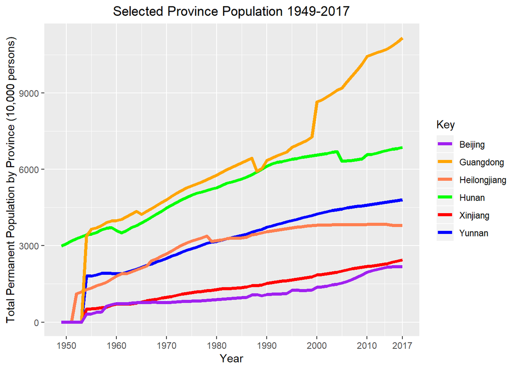

Below is a correlation test to see if there is any relationship between the increased output and decreased # of enterprises of municipalities. Beijing and Shanghai are used as sample municipalities.

[The Pearson Correlation](https://support.minitab.com/en-us/minitab-express/1/help-and-how-to/modeling-statistics/regression/supporting-topics/basics/a-comparison-of-the-pearson-and-spearman-correlation-methods/) method was used in this test to evaluate the linear relationship between the two variables. This test shows whether or not one change in a variable is associated with a proportional change in the other variable.

For the purpose of the correlation test, year 2017 was removed from Beijing’s data due to N/A values being present, as well as 1949-1951 in Shanghai’s data due to N/A values being present.

```
##
##  Pearson's product-moment correlation
##
## data:  Beijing_Output_Cor and Beijing_Enterprise_Cor
## t = -1.144, df = 66, p-value = 0.2568
## alternative hypothesis: true correlation is not equal to 0
## 95 percent confidence interval:
##  -0.3657064  0.1023896
## sample estimates:
##        cor
## -0.1394395
```

```
##
##  Pearson's product-moment correlation
##
## data:  Shanghai_Output_Cor and Shanghai_Enterprise_Cor
## t = 0.25935, df = 64, p-value = 0.7962
## alternative hypothesis: true correlation is not equal to 0
## 95 percent confidence interval:
##  -0.2112879  0.2722992
## sample estimates:
##        cor
## 0.03240188
```

According to the results, there is a negative correlation of -0.1394395 in Beijing’s test, and a positive correlation of 0.03240188 in Shanghai’s test. The conclusion can be made that municipalities increase and decrease of output and enterprises are independent of one another. The negative correlation in Beijing’s test means as one variable increases, the other decreases. In this case, as Beijing’s # of enterprises decreases as its output increases. Though, this does not directly mean that Beijing’s decrease in enterprises is the **cause** of Beijing’s increase in output.

Shanghai’s positive correlation means that the two variables move in tandem with one another. As one increases, the other increases. Though, being such a low value, the strength of the positive correlation is low.

# Below is the aggregated data of enterprises, output, and population by region.

|  | year | n_ent | n_output | ne_ent | ne_output | e_ent | e_output | scentral_ent | scentral_output | sw_ent | sw_output | nw_ent | nw_output | n_pop | ne_pop | e_pop | scentral_pop | sw_pop | nw_pop |
| --- | --- | --- | --- | --- | --- | --- | --- | --- | --- | --- | --- | --- | --- | --- | --- | --- | --- | --- | --- |
| 1 | 1949 | 35871 | 19.08 | 16604 | 22.97 |  |  |  |  |  |  | 5703 | 5.43 | 4974.96 | 1831 | 4826 | 11586.77 | 0 | 968.45 |
| 2 | 1950 |  | 29.11 | 19801 | 40.45 |  |  |  |  |  |  | 6418 | 6.33 | 4458.57 | 1876 | 5151.1 | 7582.96 | 0 | 1012.56 |
| 3 | 1951 |  | 42.4 | 22221 | 51.18 |  |  |  |  |  |  | 7550 | 7.82 | 4556.94 | 1889 | 5299.9 | 7784.25 | 0 | 1037.42 |
| 4 | 1952 | 46692 | 46.86 | 20007 | 72.56 | 194895 | 139.48 | 112051 | 46.99 |  |  | 8354 | 9.97 | 5383.1 | 3042.5 | 6664.7 | 12336.4 | 0 | 1226.07 |
| 5 | 1953 |  | 68 | 20145 | 97.08 |  | 180.48 |  |  |  |  | 8497 | 12.97 | 4769.78 | 3228.7 | 5512.3 | 8132.7 | 0 | 1250.64 |
| 6 | 1954 |  | 81.27 | 18148 | 108.94 |  | 194.63 |  |  |  |  | 10651 | 16.17 | 6444 | 4412.3 | 18574.1 | 16305.59 | 9807 | 3696.5 |
| 7 | 1955 |  | 87.93 | 14277 | 112.56 |  | 194.51 |  |  |  |  | 8925 | 18.58 | 6971.1 | 4776.5 | 18936.3 | 16589.6 | 10414.4 | 3777.1 |
| 8 | 1956 |  | 104.91 | 11749 | 149.56 |  | 241.85 |  |  |  |  | 7641 | 21.65 | 7190.1 | 4981.6 | 19203.4 | 16862.9 | 10669.9 | 3920.4 |
| 9 | 1957 | 12755 | 97.43 | 12978 | 172.93 | 79239 | 276.09 | 53686 | 107.58 |  |  | 9244 | 23.54 | 7389.6 | 5150.1 | 19826 | 17303.3 | 10941.8 | 4042.5 |
| 10 | 1958 |  | 195.12 | 51074 | 256.39 |  | 440.71 |  |  |  |  | 26652 | 38.92 | 7572.2 | 5317.7 | 20172.1 | 17716.6 | 11069.8 | 4145.9 |

[output cut: 59 more lines]